# Python for Data Science

In this course, we use Python as our main tool for data analysis and visualization. Most of you already have Python experience, so this notebook isn't about teaching you Python from scratch. Instead, it's about:

1. **Making sure your environment is set up** for the work we'll do
2. **Orienting you toward the data science ecosystem** (pandas, matplotlib, etc.)
3. **Establishing expectations** around tools like LLMs

If you're comfortable with Python, skim through and make sure you can do the self-assessment exercises. If you struggle with those, dig deeper, follow a couple of tutorials - it's important that you're familiar with Pything before diving into the course material.

## Part 1: Setting Up Your Environment

You have several options for running Python notebooks in this course:

### Option A: Local Installation with Anaconda (Recommended)

For a local setup, we recommend the [Anaconda distribution](https://www.anaconda.com/download). It includes Python, Jupyter, and most libraries you'll need.

Once installed, you can start notebooks by:

- Running `jupyter notebook` in your terminal (classic interface), or
- Running `jupyter lab` for the more modern JupyterLab interface (I use Notebooks, but I'm old fashioned)

### Option B: Google Colab (Easiest)

[Google Colab](https://colab.research.google.com/) lets you run Jupyter notebooks in your browser with zero installation. It comes with most data science libraries pre-installed. This is a great option if you want to get started immediately or if you're having installation troubles. But then you're sharing your data with Google ... and you might have issues with large files.

### Option C: VS Code with Jupyter Extension

If you prefer a full IDE, [VS Code](https://code.visualstudio.com/) with the [Jupyter extension](https://marketplace.visualstudio.com/items?itemName=ms-toolsai.jupyter) is excellent. It gives you the notebook experience inside a proper code editor with git integration, debugging, and more.

### Whichever you choose

There are many other useful setups, so in the end, just make sure you can open this notebook and run the cells below before proceeding.

## Part 2: Python Self-Assessment

Before we get into data science specifics, let's make sure you're comfortable with core Python. Download this Notebook to your local system and complete the exercises below directly in the notebook. If you can do these without much trouble, it means that you're ready for the course.

### Exercise 2.1: List Comprehensions

Create a list of the squares of all even numbers from 0 to 20.

```python
# Your code here
```

### Exercise 2.2: Dictionaries

Given the dictionary below, write code that prints each person's name and their age in 10 years.

```python
people = {
    "Alice": 28,
    "Bob": 35,
    "Charlie": 42
}

# Your code here
```

### Exercise 2.3: Functions

Write a function that takes a list of numbers and returns a dictionary with the keys `"min"`, `"max"`, and `"mean"` containing the respective values.

```python
def summarize(numbers):
    # Your code here
    pass

# Test it:
# summarize([1, 2, 3, 4, 5]) should return {"min": 1, "max": 5, "mean": 3.0}
```

### Exercise 2.4: Working with JSON

The cell below contains a JSON string. Parse it and print the title of each book along with its author.

```python
import json

json_string = '''
{
    "library": "City Library",
    "books": [
        {"title": "1984", "author": "George Orwell", "year": 1949},
        {"title": "Brave New World", "author": "Aldous Huxley", "year": 1932},
        {"title": "Fahrenheit 451", "author": "Ray Bradbury", "year": 1953}
    ]
}
'''

# Your code here
```

### Need more practice?

If you found these exercises difficult, work through the training notebook [here](https://raw.githubusercontent.com/suneman/socialdata2022/main/files/Training_notebook.ipynb) before continuing. (**Hint**: Be careful not to save it in *.txt* format - make sure the extension is *.ipynb*.)

If you need a more comprehensive Python refresher, try learnpython.org.

## Part 3: Using LLMs for Coding

Large Language Models have transformed how we write code. In this course, we encourage you to use LLMs as coding assistants, but with intention.

### When LLMs are helpful

- **Boilerplate code**: Setting up plots, reading files, standard data transformations
- **Debugging**: "Why am I getting this error?" often gets good answers
- **Learning new libraries**: "How do I do X in pandas?" is faster than searching docs (although I feel ambivalent about this since it means great sites like stackoverflow are dying)
- **Code explanation**: Understanding unfamiliar code you encounter
- **Styling plots and making them look good**: If you can tell an LLM what you want a plot to look like, it can save lots of time with matplotlib documentation.

### When to be careful

- **Core concepts**: If you don't understand *why* something works, you'll struggle to adapt it
- **Analysis decisions**: LLMs don't know your data or research questions
- **Blindly copying**: Always read and understand code before using it
- **Complex logic**: LLMs can confidently produce subtly wrong code

### My expectation

You should be able to explain any code you submit. If you used an LLM to help write parts of it, that's fine, but make sure you understand what it does and why. The goal is learning, and LLMs are a tool to help you learn. The trouble is that usually it means that you avoid learning.

## Part 4: Pandas Essentials

Pandas is the backbone of much of data analysis in Python. Think of it as Excel with superpowers. Let's walk through the essentials you'll use constantly in this course.

For a more comprehensive introduction, see the official [10 Minutes to Pandas](https://pandas.pydata.org/pandas-docs/stable/user_guide/10min.html) tutorial.

```python
import pandas as pd
import numpy as np
```

### Creating DataFrames

A DataFrame is a 2D table with labeled rows and columns.

```python
# From a dictionary
df = pd.DataFrame({
    "city": ["Copenhagen", "Aarhus", "Odense", "Aalborg"],
    "population": [794128, 285273, 180302, 119862],
    "area_km2": [88.25, 91.00, 304.34, 139.00]
})

df
```

|  | city | population | area_km2 |
| --- | --- | --- | --- |
| 0 | Copenhagen | 794128 | 88.25 |
| 1 | Aarhus | 285273 | 91.00 |
| 2 | Odense | 180302 | 304.34 |
| 3 | Aalborg | 119862 | 139.00 |

### Selecting Data

Use `.loc[]` for label-based selection and `.iloc[]` for position-based selection.

```python
# Select a single column (returns a Series)
df["city"]
```

```
0    Copenhagen
1        Aarhus
2        Odense
3       Aalborg
Name: city, dtype: object
```

```python
# Select multiple columns (returns a DataFrame)
df[["city", "population"]]
```

|  | city | population |
| --- | --- | --- |
| 0 | Copenhagen | 794128 |
| 1 | Aarhus | 285273 |
| 2 | Odense | 180302 |
| 3 | Aalborg | 119862 |

```python
# Select rows by condition
df[df["population"] > 200000]
```

|  | city | population | area_km2 |
| --- | --- | --- | --- |
| 0 | Copenhagen | 794128 | 88.25 |
| 1 | Aarhus | 285273 | 91.00 |

```python
# Select specific rows and columns with .loc
df.loc[df["population"] > 200000, ["city", "population"]]
```

|  | city | population |
| --- | --- | --- |
| 0 | Copenhagen | 794128 |
| 1 | Aarhus | 285273 |

### Creating New Columns

```python
# Calculate population density
df["density"] = df["population"] / df["area_km2"]
df
```

|  | city | population | area_km2 | density |
| --- | --- | --- | --- | --- |
| 0 | Copenhagen | 794128 | 88.25 | 8998.617564 |
| 1 | Aarhus | 285273 | 91.00 | 3134.868132 |
| 2 | Odense | 180302 | 304.34 | 592.436091 |
| 3 | Aalborg | 119862 | 139.00 | 862.316547 |

### Basic Statistics

```python
# Quick summary statistics
df.describe()
```

|  | population | area_km2 | density |
| --- | --- | --- | --- |
| count | 4.000000 | 4.000000 | 4.000000 |
| mean | 344891.250000 | 155.647500 | 3397.059583 |
| std | 307189.289014 | 101.830449 | 3904.571311 |
| min | 119862.000000 | 88.250000 | 592.436091 |
| 25% | 165192.000000 | 90.312500 | 794.846433 |
| 50% | 232787.500000 | 115.000000 | 1998.592339 |
| 75% | 412486.750000 | 180.335000 | 4600.805490 |
| max | 794128.000000 | 304.340000 | 8998.617564 |

```python
# Individual statistics
print(f"Total population: {df['population'].sum():,}")
print(f"Mean population: {df['population'].mean():,.0f}")
print(f"Max density: {df['density'].max():,.0f} people/km2")
```

```
Total population: 1,379,565
Mean population: 344,891
Max density: 8,999 people/km2
```

### Reading Data from Files

In this course, you'll often load data from CSV files or URLs.

```python
# From a CSV file:
# df = pd.read_csv("path/to/file.csv")

# From a URL:
# df = pd.read_csv("https://example.com/data.csv")

# From JSON:
# df = pd.read_json("data.json")
```

### Exercise 4.1: Pandas Practice

Using the `df` DataFrame above:

1. Find the city with the lowest population density
2. Create a new column called `"population_pct"` showing each city's percentage of the total population
3. Filter to show only cities where population percentage is above 10%

```python
# Your code here
```

## Part 5: Matplotlib Basics

Matplotlib is Python's foundational plotting library. While there are many visualization libraries built on top of it, understanding matplotlib gives you full control over your visualizations.

Full documentation: [matplotlib.org](https://matplotlib.org/)

```python
import matplotlib.pyplot as plt
```

### Basic Line Plot

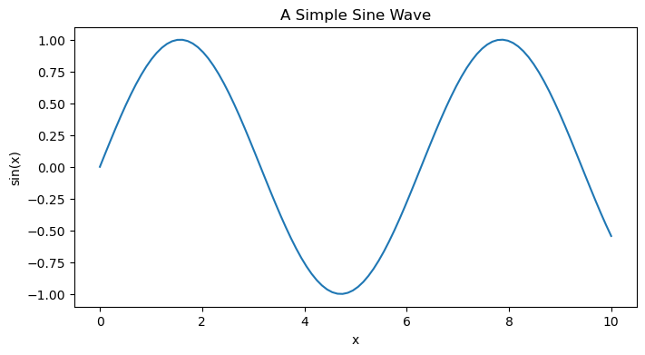

```python
x = np.linspace(0, 10, 100)
y = np.sin(x)

plt.figure(figsize=(8, 4))
plt.plot(x, y)
plt.xlabel("x")
plt.ylabel("sin(x)")
plt.title("A Simple Sine Wave")
plt.show()
```

### Bar Chart

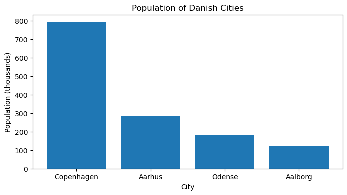

```python
plt.figure(figsize=(8, 4))
plt.bar(df["city"], df["population"] / 1000)
plt.xlabel("City")
plt.ylabel("Population (thousands)")
plt.title("Population of Danish Cities")
plt.show()
```

### Scatter Plot

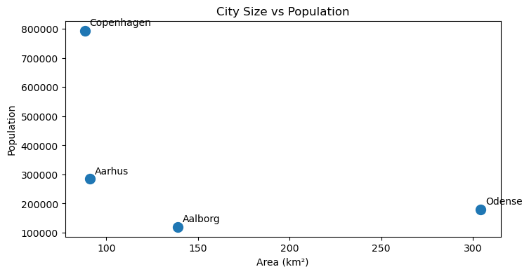

```python
plt.figure(figsize=(8, 4))
plt.scatter(df["area_km2"], df["population"], s=100)

# Add city labels
for i, city in enumerate(df["city"]):
    plt.annotate(city, (df["area_km2"].iloc[i], df["population"].iloc[i]),
                 textcoords="offset points", xytext=(5, 5))

plt.xlabel("Area (km²)")
plt.ylabel("Population")
plt.title("City Size vs Population")
plt.show()
```

### Subplots

Often you'll want multiple plots side by side.

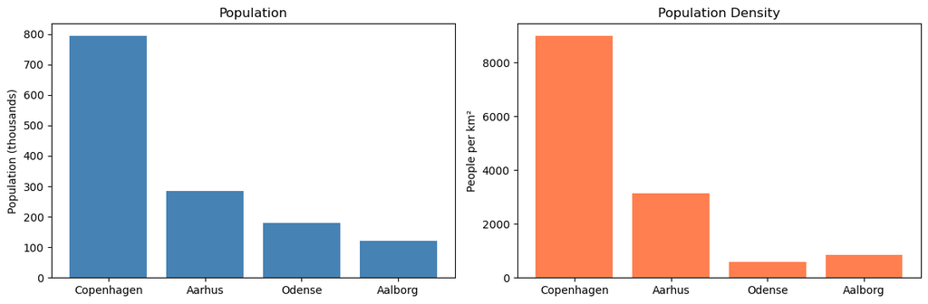

```python
fig, axes = plt.subplots(1, 2, figsize=(12, 4))

# Left plot: population
axes[0].bar(df["city"], df["population"] / 1000, color="steelblue")
axes[0].set_ylabel("Population (thousands)")
axes[0].set_title("Population")

# Right plot: density
axes[1].bar(df["city"], df["density"], color="coral")
axes[1].set_ylabel("People per km²")
axes[1].set_title("Population Density")

plt.tight_layout()
plt.show()
```

### Exercise 5.1: Create a Visualization

Create a horizontal bar chart showing the population density of each city, sorted from highest to lowest density. Add appropriate labels and a title.

```python
# Your code here
```

## Part 6: Ready to Go?

If you've completed the exercises in this notebook without major difficulty, you're ready for the course.

### If you're struggling

Programming is a prerequisite for this course. If the exercises above were difficult, please take time now to improve your Python skills before proceeding (it will make you a better thinker too, so it's totally worth the effort). It will be very hard to keep up with the course material if you're also learning Python at the same time.

Resources:

- [Learn Python](https://www.learnpython.org) - Interactive Python tutorial
- [10 Minutes to Pandas](https://pandas.pydata.org/pandas-docs/stable/user_guide/10min.html) - Official pandas tutorial
- [Matplotlib Tutorials](https://matplotlib.org/stable/tutorials/index.html) - Official matplotlib tutorials